# Day 9 - PCA Load Profiles

Bryan Goodrich

January 9, 2017

# An Exploratory Analysis

I forget what exactly I was looking at ([but this is good](https://tgmstat.wordpress.com/2013/11/28/computing-and-visualizing-pca-in-r/)); I was reading up on PCA and SVD approaches. After trying to find some good examples, I decided to just toy around with the electricity load data from Day 2.

### Data Prep

```r
infile <- "data/RefBldgMediumOfficeNew2004_7.1_5.0_3B_USA_CA_LOS_ANGELES.csv"
x <- read.csv(infile, as.is = TRUE)[1:2]  # Only using Electricity
names(x) <- c("datetime", "kwh")
dt <- do.call(rbind, lapply(strsplit(x$datetime, ' +'), parser('%m/%d')))

x <- data.frame(x, dt)  # Hourly Grain
y <- reshape2::dcast(x, day ~ hour, value.var = 'kwh')  # Daily Grain
```

### PCA Visuals

I’m not entirely sure how to interpret the biplot between the two groupings, but as is manually plotted, there is a clear separation between the weekday and the weekend usage patterns in these components.

I wanted to see if the rotation vectors would show correlation among certain hours. Maybe we can use PCA to identify meaningful hours of peak usage or ramp-up/ramp-down times as an easier way to segment customers. It’s hard to read, but it almost looks like the ramp-down hours are most grouped together where the data points arc. Any thoughts?

At the end, we can see the distinct difference in weekend vs weekday behavior when we plot all 365 load profiles, colored by day of the week.

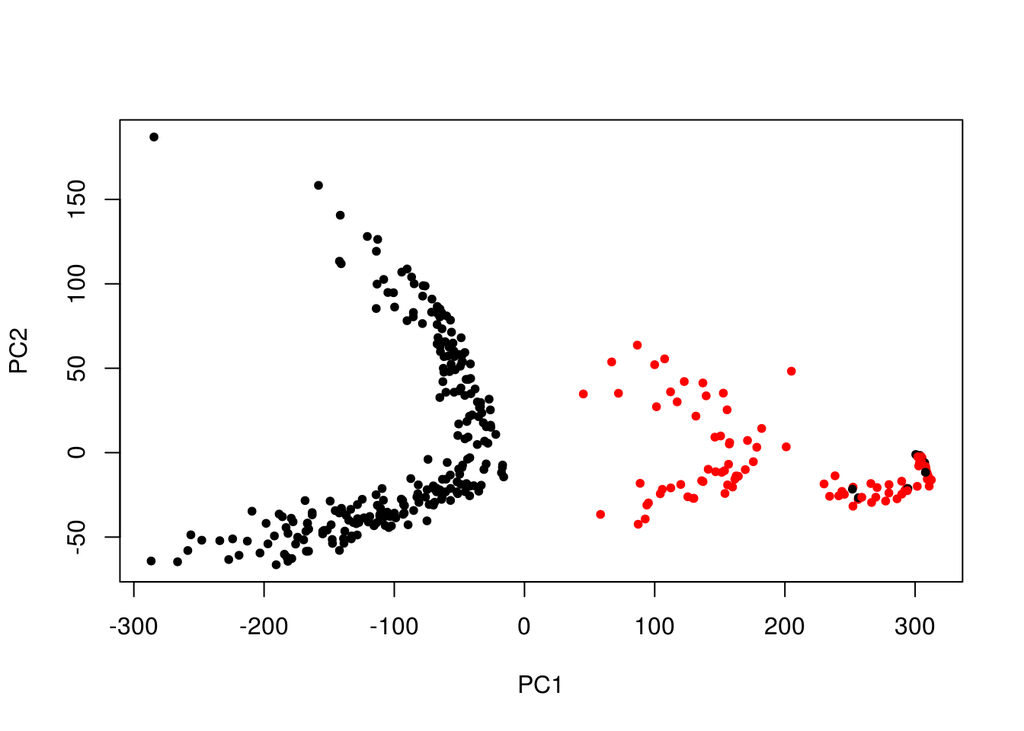

```r
pca <- prcomp(y[-1])
p <- data.frame(pca$x[, 1:2])  # Grab out the 1st two principal components
p$weekday <- weekdays(y$day)
p$weekend <- ifelse(p$weekday %in% c("Sunday", "Saturday"), 2, 1)
plot(PC2 ~ PC1, p, pch = 20, col = weekend)  # Weekends are Red
```

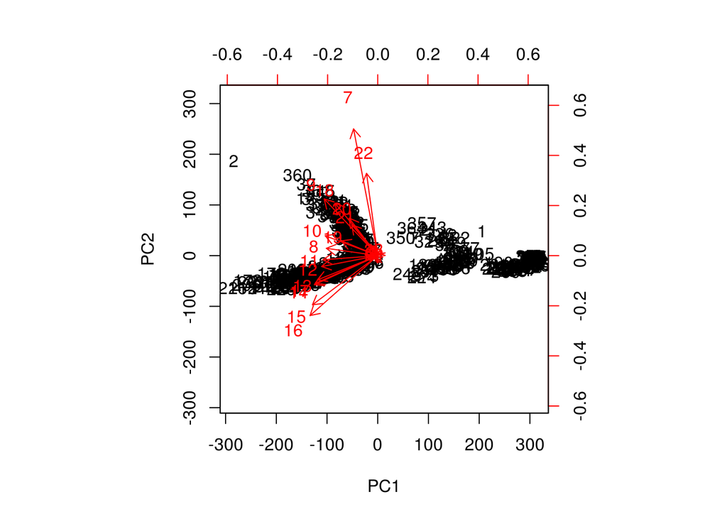

```r
biplot(pca, scale = 0)
```

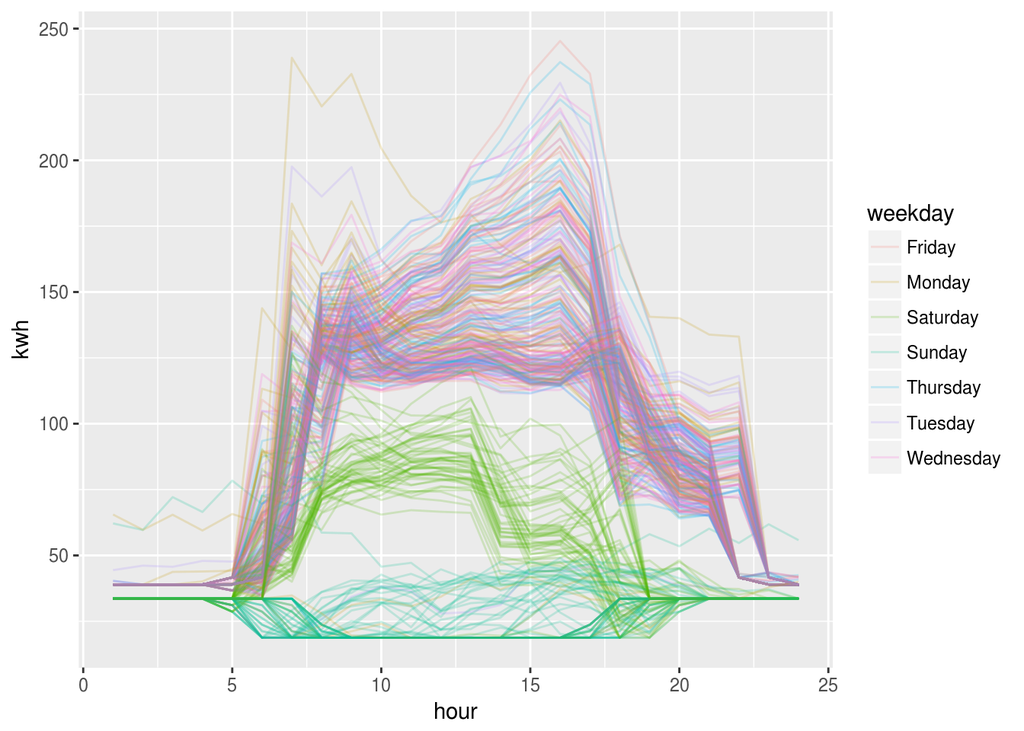

```r
x$weekday <- weekdays(x$day)  # For coloring
ggplot(x) + aes(hour, kwh, group = day, color = weekday) + geom_line(alpha = .2)
```

### Closing Remarks

I’m not entirely sure how to make use of PCA, but it was neat to see how cleanly it picked apart the weekday vs weekend. I also ran this (not shown) for the residential example I used in Day 2, and there was no difference between weekend/weekday. This suggests to me either the data is bogus in reflecting real home usage, or it’s resembles a very unique type of residential behavior. Typical behavior there usually distinct days that are different from one another. Or maybe the PCA approach just didn’t work in that case, but works well in this case. It spurs curiosity I’ll have to explore later. More energy analytics to come, on another day!

…